# Lecture 7: Exploratory Data Analysis

Nick Huntington-Klein

28 February, 2023

## The Purpose of Analysis

- What are we even *doing* with data?
- We want to see what sorts of stuff is in the data, so that we know what things we *should* be reporting on
- This requires us to *explore* the data
- Even if we come in with a strong idea of what we want to find, learning about what the data looks like is a good idea

## The Purpose of Analysis

We want to:

- Understand our data (read the docs, too!!!)
- Detect mistakes
- Get a sense of what our variables look like
- Figure out what some of the relationships are

## The Purpose of Analysis

Always be on the lookout (in EDA and in your code!)

- Things that are different that shouldn’t be different (“why does this one person have a height 8x that of anyone else?”)
- Things that are the same that shouldn’t be the same (“Why is the mean income for Americans and Canadians exactly preciely the same to the 8th decimal place?”)
- Relationships that are very surprising (“Why is age negatively correlated with height?”)

## Exploring Data

- Univariate non-graphical
- Univariate graphical
- Multivariate non-graphical
- Multivariate graphical

## Univariate Exploratory Analysis

Looking for:

- What kind of values we have
- Are there massive outliers? Are there values that look *incorrect*?
- What is the distribution? Is there skew? If it’s a factor, does one category dominate?
- You’ll want to do this with nearly every variable you have
- Getting all the little presentation details is less important, but the graph should still be readable (labels etc.) On that note, EDA isn’t always *concise* - some tables/graphs will slip off the edge of these slides.

## Univariate Exploratory Analysis

- Think about *what features of the variable it makes sense to explore*
- Central tendencies (mean, median, etc.?)
- Tails? Skew? Percentiles?
- If it’s a factor, is showing *all* the categories informative? Do you need to collapse first? Or summarize?

## Univariate Exploratory Analysis Tools

- `summary()` shows lots of good info about a variable’s distribution (also works to summarize other objects)

```r
summary(iris$Sepal.Length)
```

```
##    Min. 1st Qu.  Median    Mean 3rd Qu.    Max.
##   4.300   5.100   5.800   5.843   6.400   7.900
```

```r
summary(iris$Species)
```

```
##     setosa versicolor  virginica
##         50         50         50
```

## Univariate Exploratory Analysis Tools

- `str()` shows variable classes (important!) and some values

```r
str(iris)
```

```
## 'data.frame':    150 obs. of  5 variables:
##  $ Sepal.Length: num  5.1 4.9 4.7 4.6 5 5.4 4.6 5 4.4 4.9 ...
##  $ Sepal.Width : num  3.5 3 3.2 3.1 3.6 3.9 3.4 3.4 2.9 3.1 ...
##  $ Petal.Length: num  1.4 1.4 1.3 1.5 1.4 1.7 1.4 1.5 1.4 1.5 ...
##  $ Petal.Width : num  0.2 0.2 0.2 0.2 0.2 0.4 0.3 0.2 0.2 0.1 ...
##  $ Species     : Factor w/ 3 levels "setosa","versicolor",..: 1 1 1 1 1 1 1 1 1 1 ...
```

## Univariate Exploratory Analysis Tools

- `vtable()` in **vtable** is a more readable and flexible version of that. `lush = TRUE` for more info

```r
library(vtable)
vtable(iris, lush = TRUE)
```

iris

| Name | Class | Values | Missing | Summary |
| --- | --- | --- | --- | --- |
| Sepal.Length | numeric | Num: 4.3 to 7.9 | 0 | mean: 5.843, sd: 0.828, nuniq: 35 |
| Sepal.Width | numeric | Num: 2 to 4.4 | 0 | mean: 3.057, sd: 0.436, nuniq: 23 |
| Petal.Length | numeric | Num: 1 to 6.9 | 0 | mean: 3.758, sd: 1.765, nuniq: 43 |
| Petal.Width | numeric | Num: 0.1 to 2.5 | 0 | mean: 1.199, sd: 0.762, nuniq: 22 |
| Species | factor | ‘setosa’ ‘versicolor’ ‘virginica’ | 0 | nuniq: 3 |

## Univariate Exploratory Analysis Tools

- `sumtable()` in **vtable** is a full table of summary statistics

```r
sumtable(iris)
```

Summary Statistics

| Variable | N | Mean | Std. Dev. | Min | Pctl. 25 | Pctl. 75 | Max |
| --- | --- | --- | --- | --- | --- | --- | --- |
| Sepal.Length | 150 | 5.843 | 0.828 | 4.3 | 5.1 | 6.4 | 7.9 |
| Sepal.Width | 150 | 3.057 | 0.436 | 2 | 2.8 | 3.3 | 4.4 |
| Petal.Length | 150 | 3.758 | 1.765 | 1 | 1.6 | 5.1 | 6.9 |
| Petal.Width | 150 | 1.199 | 0.762 | 0.1 | 0.3 | 1.8 | 2.5 |
| Species | 150 |  |  |  |  |  |  |
| … setosa | 50 | 33.3% |  |  |  |  |  |
| … versicolor | 50 | 33.3% |  |  |  |  |  |
| … virginica | 50 | 33.3% |  |  |  |  |  |

## Univariate Exploratory Analysis Tools

- Moving on to graphical tools! In **ggplot**, `geom_density()` and `geom_histogram()` can both show full distributions (when might this *not* be useful?)

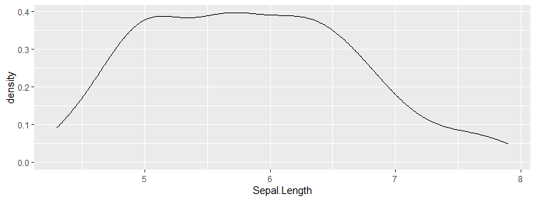

```r
ggplot(iris, aes(x = Sepal.Length)) + geom_density()
```

## Univariate Exploratory Analysis Tools

- Boxplots aren’t for general-audience consumption but they show some easy summary statistics

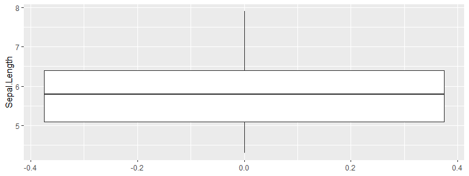

```r
ggplot(iris, aes(x = Sepal.Length)) + geom_boxplot() + coord_flip()
```

## Univariate Exploratory Analysis

- Load the `gov_transfers` data from the **causaldata** package
- Read the docs! `help(gov_transfers)`
- Explore the variables that are in there on a univariate basis

## Multivariate Exploratory Analysis

- We want to know *how variables are related* in multivariate analysis
- Again, *fit the analysis to the context*. Don’t treat a continuous variable as a factor, and if you treat a discrete variable as continuous know that a scatterplot won’t work! etc.
- Don’t just fire and forget. Think about whether the output is actually informative.
- more than 2 variables are possible too! Just add more groups/aesthetics.

## Multivariate Exploratory Analysis Tools

- For continuous vs. continuous, nothing wrong with starting with a linear correlation!
- Bivariate OLS is just a rescaled correlation

```r
cor(iris$Sepal.Length, iris$Sepal.Width)
```

```
## [1] -0.1175698
```

```r
lm(Sepal.Length ~ Sepal.Width, data = iris)
```

```
##
## Call:
## lm(formula = Sepal.Length ~ Sepal.Width, data = iris)
##
## Coefficients:
## (Intercept)  Sepal.Width
##      6.5262      -0.2234
```

## Multivariate Exploratory Analysis Tools

- If one variable is discrete or a factor, don’t underestimate plain ol’ `group_by() %>% summarize()`
- In fact, many headaches of trying to get R to do something for you can be avoided by just doing `group_by() %>% summarize()` yourself
- Don’t forget `na.rm = TRUE` as appropriate

```r
iris %>%
  group_by(Species) %>%
  summarise(mean.SL = mean(Sepal.Length, na.rm = TRUE),
            sd.SL = sd(Sepal.Length, na.rm = TRUE))
```

```
## # A tibble: 3 × 3
##   Species    mean.SL sd.SL
##   <fct>        <dbl> <dbl>
## 1 setosa        5.01 0.352
## 2 versicolor    5.94 0.516
## 3 virginica     6.59 0.636
```

## Multivariate Exploratory Analysis Tools

- `sumtable` has a `group` option for the same purpose (note `summ` can customize the summary functions)

```r
iris %>% sumtable(group = 'Species')
```

Summary Statistics

| Species Variable | setosa N | setosa Mean | setosa SD | versicolor N | versicolor Mean | versicolor SD | virginica N | virginica Mean | virginica SD |
| --- | --- | --- | --- | --- | --- | --- | --- | --- | --- |
| Sepal.Length | 50 | 5.006 | 0.352 | 50 | 5.936 | 0.516 | 50 | 6.588 | 0.636 |
| Sepal.Width | 50 | 3.428 | 0.379 | 50 | 2.77 | 0.314 | 50 | 2.974 | 0.322 |
| Petal.Length | 50 | 1.462 | 0.174 | 50 | 4.26 | 0.47 | 50 | 5.552 | 0.552 |
| Petal.Width | 50 | 0.246 | 0.105 | 50 | 1.326 | 0.198 | 50 | 2.026 | 0.275 |

## Multivariate Exploratory Analysis Tools

- `tabyl` in **janitor** is great for discrete vs. discrete; use `adorn` functions to get percents instead of counts. Watch the denominator! It affects interpretation a LOT

```r
library(janitor)
mtcars %>% tabyl(am, vs) %>%
  adorn_percentages(denominator = 'row') %>%
  adorn_pct_formatting() %>% adorn_title()
```

```
##        vs
##  am     0     1
##   0 63.2% 36.8%
##   1 46.2% 53.8%
```

## Multivariate Exploratory Analysis

- Moving on to graphs!
- If one variable is a factor/discrete you can do pretty much any kind of graph you like, but grouped

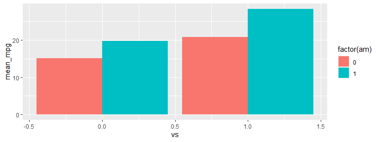

```r
mtcars %>% group_by(vs, am) %>%
  summarize(mean_mpg = mean(mpg)) %>%
  ggplot(aes(x = vs, fill = factor(am), y = mean_mpg)) + geom_col(position = 'dodge')
```

## Multivariate Exploratory Analysis

- When it comes to densities, typical geoms look cluttered. I recommend `geom_density_ridges` in **ggridges**, or `geom_violin` (or use facets)

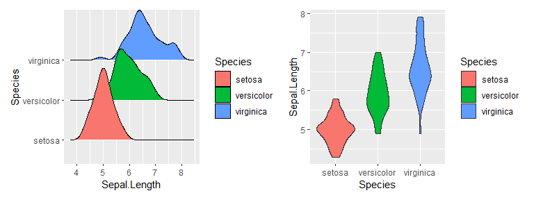

```r
library(ggridges); library(patchwork)
p1 <- ggplot(iris, aes(x = Sepal.Length, y = Species, fill = Species)) + geom_density_ridges()
p2 <- ggplot(iris, aes(x = Species, y = Sepal.Length, fill = Species)) + geom_violin()
p1 + p2
```

## Multivariate Exploratory Analysis

- For two continuous variables, things can be tricky, but a scatterplot is a good place to start

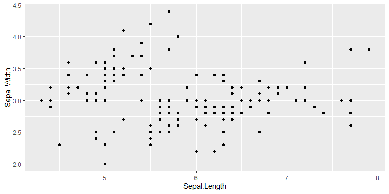

```r
ggplot(iris, aes(x = Sepal.Length, y = Sepal.Width)) + geom_point()
```

## Automation

- As a starting place, `ggpairs` in **GGally** will automatically pick univariate and multivariate comparisons to start

```r
GGally::ggpairs(iris)
```

## Automation

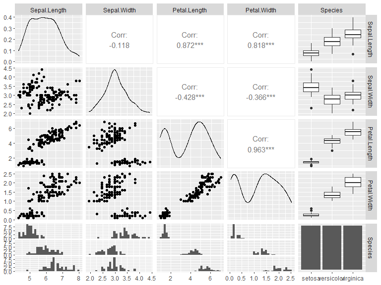

## Multivariate Exploratory Analysis

- Let’s do some of this in our `gov_transfers` data!

## Going into Detail

- This has all been running with little input from us at this point
- Yes we have to figure out which kind makes sense but we’re just exploring
- Going for a bit more detail requires us to have a *question* to answer, and then we can look into that
- This targets us towards the variables/relationships to study, and *how* to explore them further
- Perhaps, for example, checking trivariate relationships, one example being “*in this subgroup* how are X and Y related?”

## Careful!

Be aware of what EDA does not do:

- Checking *every* relationship will tend to uncover non-real relationships by random chance
- Consider doing EDA on a random subset data for this reason, so you can check if something interesting actually is there in the other/full data and don’t trick yourself
- Hardly ever establishes a *causal relationship* - avoid causal language unless you can really back it up!

## Let’s Do More (if there’s time)

- https://vincentarelbundock.github.io/Rdatasets/csv/Stat2Data/Clothing.csv
- Data description: https://rdrr.io/rforge/Stat2Data/man/Clothing.html
- Explore! What do we find?